# Intro to Data Visualization in R for Research

## Session Contents

- Intro to the Tidyverse
- Plotting in R, *plot* vs *ggplot2*
- Basics of ggplot2
  - Core Functions
  - Layering & Aesthetic Mapping
  - Chart types (using Geoms)
  - Colours, Shapes and Size
  - Other Aesthetic Details

## Objectives and Transferable Skills

- To be able to:
  - Begin to generate simple visualizations from novel data
  - Begin to utilize good coding and data visualization practices
  - Begin to think constructively about data visualization
- Core Skills:
  - Data visualization in R
  - Exploratory Data Analysis using visualization
  - Creative Problem solving and code debugging

## Session Layout

- 90 minutes long.
- Heavily focused on Practical, with some theory and visual demonstrations
- When working on the practical content, feel free to work on your own, in pairs, in groups!

## Schedule

**Introduction** (15 minutes)

- Intro to the Tidyverse
- *plot* vs *ggplot*

**Part 1** (30 minutes)

- Basics of ggplot2 (1)
  - Core Functions & Structure
  - Layering, Aesthetics and Chart Types

**Break** (10 minutes)

**Part 2** (25 minutes)

- Basics of ggplot2 (2)
  - Colours, shapes and size
  - Other Aesthetic Details

**Review & Conclusion** (10 minutes)

- Review our Session
- Discuss content of next session
- Sharing examples

## Introduction

## The Tidyverse

- A collection of R Packages designed specifically for data science.
- This includes packages which are considered *core* in everyday data analysis.
- These are designed to encourage uniform and consistent practice within data science programming.
- Packages include
  - *ggplot2*: Used for generating graphics
  - *dplyr*: Used for data manipulation
  - *tidyr*: Used for data cleaning and tidying
  - *readr*: Used to read and load data (like .csv, .tsv)
  - And many, many more.

## R for Data Science

- The *bible* for learning the tidyverse is [R for data science](https://r4ds.had.co.nz/)
- This covers a general introduction to Tidyverse packages and goes from complete beginners through to basic skills.
- One useful tool, are the [RStudio Cheatsheets](https://rstudio.com/resources/cheatsheets/)

## Ways to plot in R, plot vs ggplot2

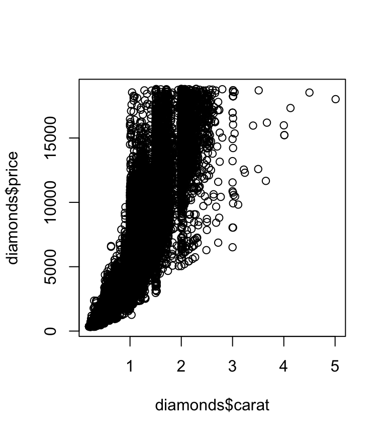

```r
plot(x = diamonds$carat,
     y = diamonds$price)
```

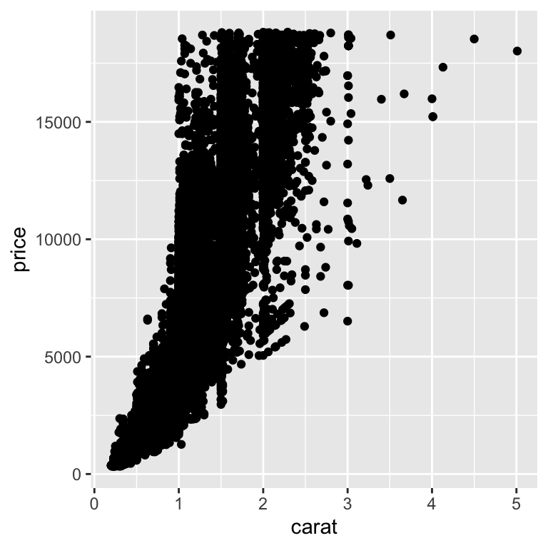

```r
ggplot(data = diamonds,
       mapping = aes(x = carat,
                     y = price)) +
  geom_point()
```

## Plot vs ggplot2

**Plot**

- Simple and Easy Method,
- Can be used quickly without much coding experience,
- Not useful for visualizing complex data or generating nice plots!

**ggplot2**

- Complex, but highly adaptive,
- Layer based, and can be used for lots of different graph types,
- Extremely useful for visualizing complex data and generating nice pleasing plots,

## Part 1

## Basics of ggplot2

- Your basic ggplot2 function contains the following:
  - Core Function

```r
ggplot()
```

- Mapping Function & Data Specification

```r
mapping = aes(x, y)
data = data
```